# Practical Machine Learning

J Rosmus

February 3, 2018

## Practical machine Learning - Predicting Exercise from Activity

### I. Overview

In this report we will look at the dat available from http://web.archive.org/web/20161224072740/http:/groupware.les.inf.puc-rio.br/har. This data utilizes accelerometers on the belt, forarm, arm, and dumbell of 6 participants as they exercise. A brief description of the work with the summary results is presented adn then followed by all of the code used in this report.

### II. Loading Data and Exploratory Analysis

A number of librariers will be needed in order to run this analysis. The first step is going to be to create the correct environment. To do this, I loaded in the appropriate libraries

The training data for this project are available here: https://d396qusza40orc.cloudfront.net/predmachlearn/pml-training.csv

The test data are available here: https://d396qusza40orc.cloudfront.net/predmachlearn/pml-testing.csv

I downloaded these sets and then looked at their dimensions. Both the training set and the test set had 160 variables. There were a number of NAs to be removed and a Near Zero Variance and ID variables were removed as well. This left 54 variables in the test and training sets.

Our aim is to figure out which exercise was done. The best place to start is to look at how the variables correlate. If you look in section II d. below, you will see a chart where the stronger correlations are in darker colors. Fortunately, the number of correlations is not huge. So we can move on to building our predictive model.

### III. Prediction Model Building

In this analysis, I am using three predictive models. i am using the Random Forest, Decision Tree, and Generalized Boosted model. The result with the highest accuracy will be used to predict the exercise. For each of the 3 methods, you can see the Confusion Matrix which details the information for cross-validation. The accuracy is given above each plot. The accuracy results are as follows: Random Forest: 0.9978 Decision Tree: 0.7359 Generalized Boost: 0.9874

For this reason, Random Forest will be used to predict the exercises done in the test set.

### IV. Predicting the test results

The final results of the prediction are: [1] B A B A A E D B A A B C B A E E A B B B Levels: A B C D E

To repeat this was done using Random Forest Model on the Training data.

### II a. setting up the environment

```r
library(knitr)
library(caret)
```

```r
library(rpart)
library(rpart.plot)
library(rattle)   # make sure you have loaded this in the console. It will prompt you to load GTK+. VERY IMPORTANT
library(randomForest)
library(corrplot)
library(e1071)
library(pillar)
library(ggplot2)
set.seed(1337)
```

### II b. Downloading data

```r
# set the URL for the download
TrainFile <- "http://d396qusza40orc.cloudfront.net/predmachlearn/pml-training.csv"
TestSet  <- "http://d396qusza40orc.cloudfront.net/predmachlearn/pml-testing.csv"

# download the datasets
training <- read.csv(url(TrainFile))
testing  <- read.csv(url(TestSet))

# create a partition with the training dataset
inTrain  <- createDataPartition(training$classe, p=0.7, list=FALSE)
TrainSet <- training[inTrain, ]
TestSet  <- training[-inTrain, ]
dim(TrainSet)
```

```
## [1] 13737   160
```

```r
dim(TestSet)
```

```
## [1] 5885  160
```

### II c. Cleaing data

```r
# remove the NZV
NZV <- nearZeroVar(TrainSet)
TrainSet <- TrainSet[, -NZV]
TestSet  <- TestSet[, -NZV]
# remove the NAs
AllNA    <- sapply(TrainSet, function(x) mean(is.na(x))) > 0.95
TrainSet <- TrainSet[, AllNA==FALSE]
TestSet  <- TestSet[, AllNA==FALSE]
# remove the ID variables
TrainSet <- TrainSet[, -(1:5)]
TestSet  <- TestSet[, -(1:5)]
dim(TrainSet)
```

```
## [1] 13737    54
```

```r
dim(TestSet)
```

```
## [1] 5885   54
```

### II d. Correlation Analysis

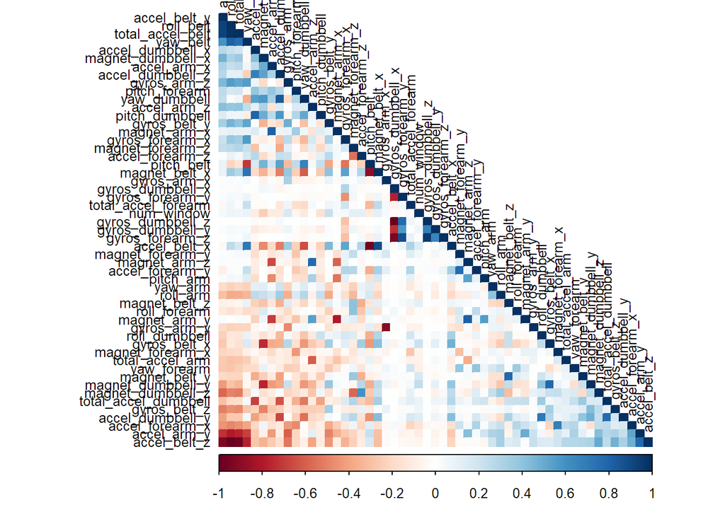

```r
corMatrix <- cor(TrainSet[, -54])
corrplot(corMatrix, order = "FPC", method = "color", type = "lower",
         tl.cex = 0.8, tl.col = rgb(0, 0, 0))
```

### III a. Random Forest

```r
set.seed(1337)
controlRF <- trainControl(method="cv", number=3, verboseIter=FALSE)
modFitRandForest <- train(classe ~ ., data=TrainSet, method="rf",
                          trControl=controlRF)
modFitRandForest$finalModel
```

```
##
## Call:
##  randomForest(x = x, y = y, mtry = param$mtry)
##                Type of random forest: classification
##                      Number of trees: 500
## No. of variables tried at each split: 27
##
##         OOB estimate of  error rate: 0.28%
## Confusion matrix:
##      A    B    C    D    E  class.error
## A 3904    1    0    0    1 0.0005120328
## B    5 2649    3    1    0 0.0033860045
## C    0    4 2390    2    0 0.0025041736
## D    0    0   11 2240    1 0.0053285968
## E    0    0    0    9 2516 0.0035643564
```

```r
predictRandForest <- predict(modFitRandForest, newdata=TestSet)
confMatRandForest <- confusionMatrix(predictRandForest, TestSet$classe)
confMatRandForest
```

```
## Confusion Matrix and Statistics
##
##           Reference
## Prediction    A    B    C    D    E
##          A 1674    3    0    0    0
##          B    0 1135    3    0    0
##          C    0    1 1022    4    0
##          D    0    0    1  960    1
##          E    0    0    0    0 1081
##
## Overall Statistics
##
##                Accuracy : 0.9978
##                  95% CI : (0.9962, 0.9988)
##     No Information Rate : 0.2845
##     P-Value [Acc > NIR] : < 2.2e-16
##
##                   Kappa : 0.9972
##  Mcnemar's Test P-Value : NA
##
## Statistics by Class:
##
##                      Class: A Class: B Class: C Class: D Class: E
## Sensitivity            1.0000   0.9965   0.9961   0.9959   0.9991
## Specificity            0.9993   0.9994   0.9990   0.9996   1.0000
## Pos Pred Value         0.9982   0.9974   0.9951   0.9979   1.0000
## Neg Pred Value         1.0000   0.9992   0.9992   0.9992   0.9998
## Prevalence             0.2845   0.1935   0.1743   0.1638   0.1839
## Detection Rate         0.2845   0.1929   0.1737   0.1631   0.1837
## Detection Prevalence   0.2850   0.1934   0.1745   0.1635   0.1837
## Balanced Accuracy      0.9996   0.9979   0.9975   0.9977   0.9995
```

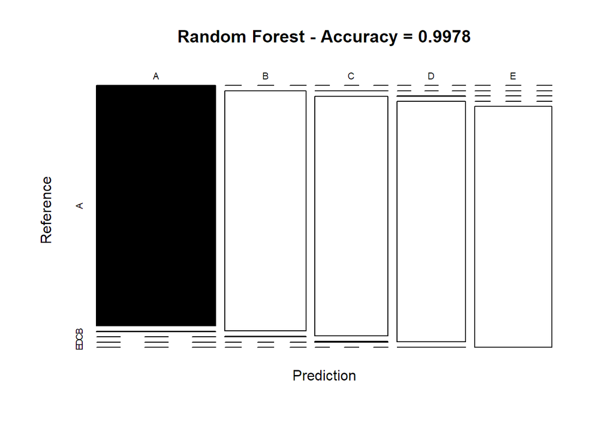

```r
plot(confMatRandForest$table, col = confMatRandForest$byClass,
     main = paste("Random Forest - Accuracy =",
     round(confMatRandForest$overall['Accuracy'], 4)))
```

### III b. Decision Tree

[figure not shown]

```r
set.seed(1337)
modFitDecTree <- rpart(classe ~ ., data=TrainSet, method="class")
fancyRpartPlot(modFitDecTree)
```

```r
predictDecTree <- predict(modFitDecTree, newdata=TestSet, type="class")
confMatDecTree <- confusionMatrix(predictDecTree, TestSet$classe)
confMatDecTree
```

```
## Confusion Matrix and Statistics
##
##           Reference
## Prediction    A    B    C    D    E
##          A 1495  202   38   65   61
##          B   54  705   78   80  112
##          C   22   68  822  144  100
##          D   80  121   64  629  129
##          E   23   43   24   46  680
##
## Overall Statistics
##
##                Accuracy : 0.7359
##                  95% CI : (0.7245, 0.7472)
##     No Information Rate : 0.2845
##     P-Value [Acc > NIR] : < 2.2e-16
##
##                   Kappa : 0.6649
##  Mcnemar's Test P-Value : < 2.2e-16
##
## Statistics by Class:
##
##                      Class: A Class: B Class: C Class: D Class: E
## Sensitivity            0.8931   0.6190   0.8012   0.6525   0.6285
## Specificity            0.9131   0.9317   0.9313   0.9199   0.9717
## Pos Pred Value         0.8033   0.6851   0.7111   0.6149   0.8333
## Neg Pred Value         0.9555   0.9106   0.9569   0.9311   0.9207
## Prevalence             0.2845   0.1935   0.1743   0.1638   0.1839
## Detection Rate         0.2540   0.1198   0.1397   0.1069   0.1155
## Detection Prevalence   0.3162   0.1749   0.1964   0.1738   0.1387
## Balanced Accuracy      0.9031   0.7753   0.8662   0.7862   0.8001
```

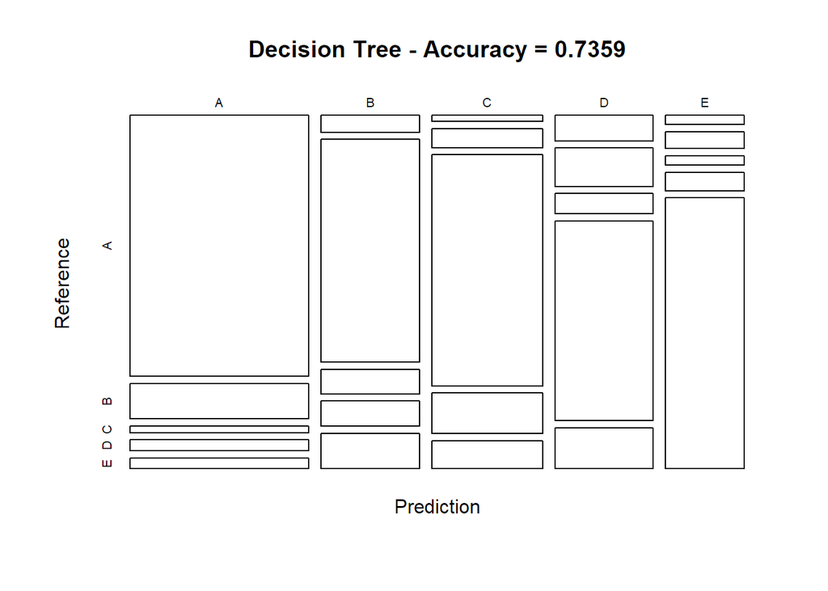

```r
plot(confMatDecTree$table, col = confMatDecTree$byClass,
     main = paste("Decision Tree - Accuracy =",
     round(confMatDecTree$overall['Accuracy'], 4)))
```

### III c. Generalized Boost Model

```r
set.seed(1337)
controlGBM <- trainControl(method = "repeatedcv", number = 5, repeats = 1)
modFitGBM  <- train(classe ~ ., data=TrainSet, method = "gbm",
                    trControl = controlGBM, verbose = FALSE)
modFitGBM$finalModel
```

```
## A gradient boosted model with multinomial loss function.
## 150 iterations were performed.
## There were 53 predictors of which 42 had non-zero influence.
```

```r
predictGBM <- predict(modFitGBM, newdata=TestSet)
confMatGBM <- confusionMatrix(predictGBM, TestSet$classe)
confMatGBM
```

```
## Confusion Matrix and Statistics
##
##           Reference
## Prediction    A    B    C    D    E
##          A 1673    8    0    0    0
##          B    1 1123   16    6    5
##          C    0    8 1007   12    1
##          D    0    0    3  942   10
##          E    0    0    0    4 1066
##
## Overall Statistics
##
##                Accuracy : 0.9874
##                  95% CI : (0.9842, 0.9901)
##     No Information Rate : 0.2845
##     P-Value [Acc > NIR] : < 2.2e-16
##
##                   Kappa : 0.9841
##  Mcnemar's Test P-Value : NA
##
## Statistics by Class:
##
##                      Class: A Class: B Class: C Class: D Class: E
## Sensitivity            0.9994   0.9860   0.9815   0.9772   0.9852
## Specificity            0.9981   0.9941   0.9957   0.9974   0.9992
## Pos Pred Value         0.9952   0.9757   0.9796   0.9864   0.9963
## Neg Pred Value         0.9998   0.9966   0.9961   0.9955   0.9967
## Prevalence             0.2845   0.1935   0.1743   0.1638   0.1839
## Detection Rate         0.2843   0.1908   0.1711   0.1601   0.1811
## Detection Prevalence   0.2856   0.1956   0.1747   0.1623   0.1818
## Balanced Accuracy      0.9988   0.9900   0.9886   0.9873   0.9922
```

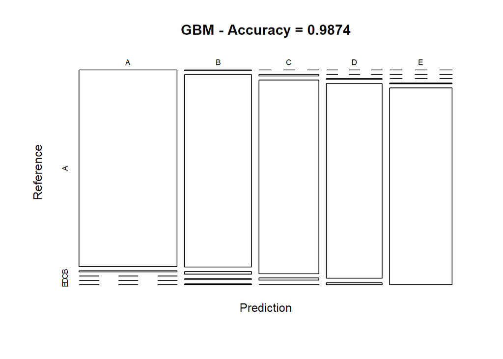

```r
plot(confMatGBM$table, col = confMatGBM$byClass,
     main = paste("GBM - Accuracy =", round(confMatGBM$overall['Accuracy'], 4)))
```

### IV. Prediction Test

```r
predictTEST <- predict(modFitRandForest, newdata=testing)
predictTEST
```

```
##  [1] B A B A A E D B A A B C B A E E A B B B
## Levels: A B C D E
```